# Movie Industry Analysis

Riley Adams, Jordan Bowman, Tracy Yu, Constanza Widel, Ruqayyah Siddique

6/6/2022

```
## [1] 7668   15
```

```r
#check for NAs
movies_test <- movies_original[movies_original$country == "United States",]

# number of NAs
sum(rowSums(is.na(movies_test)) != 0)
```

```
## [1] 1150
```

```r
# count NAs by variable
NAS_var <- colSums(is.na(movies_test))
NAS_var <- NAS_var[NAS_var != 0]
```

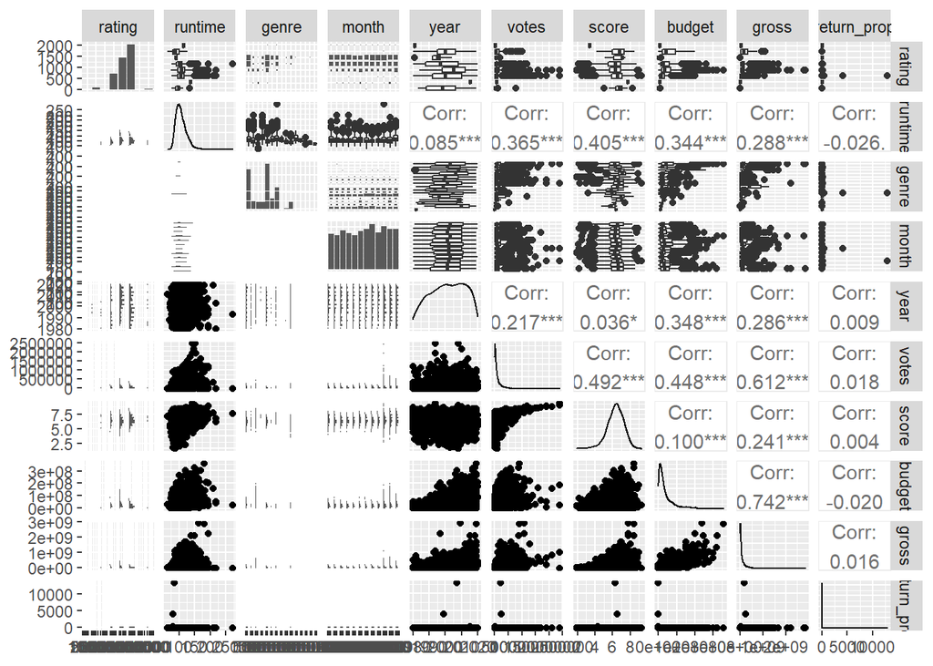

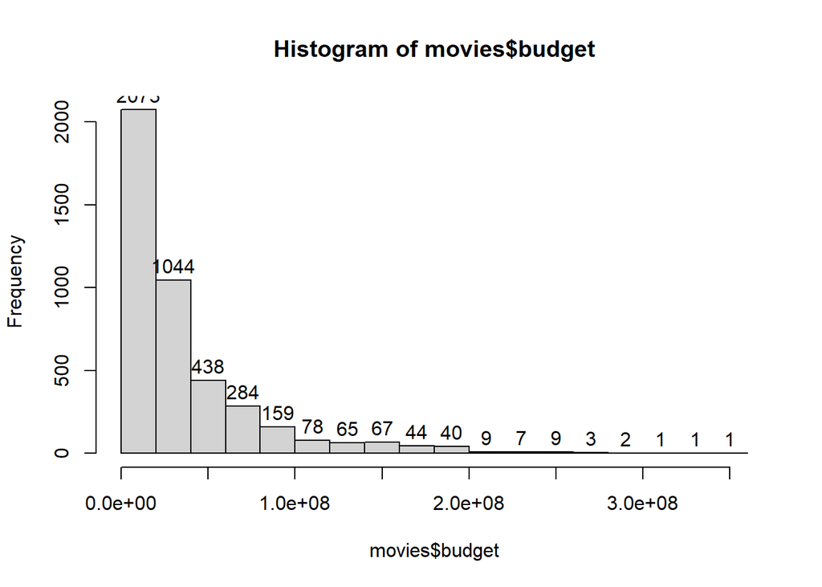

```
## [1] 0.1123699
```

```
## [1] 2000.333
```

```
## [1] 2009.117
```

```
## [1] 6.302996
```

```
## [1] 6.579835
```

Here we examine *budget* as a factor broken into two levels, based on the distribution of the histogram. Movies with a budget greater than $80,000,000 are categorized as “high” budget while those with a budget less than or equal to $80,000,000 are categorized as “low” budget. These two levels are stored as a factor *budget_cat*.

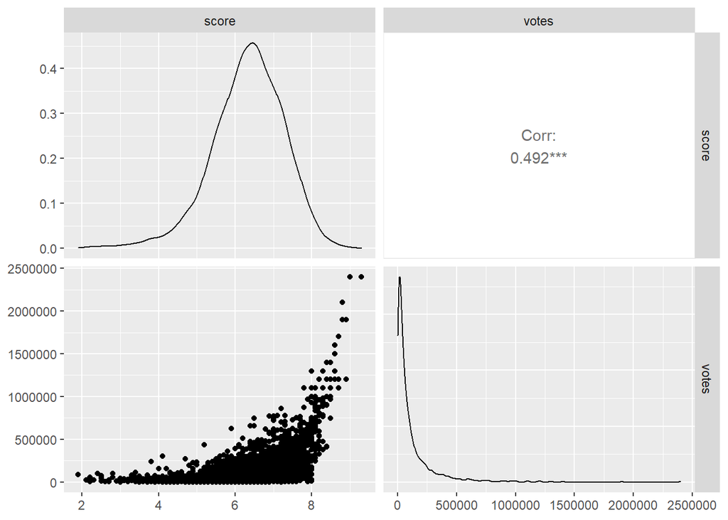

```r
# ~~~~~ Responding to Q1 ~~~~~
ggpairs(movies[c("score", "votes")])
```

```r
# From chart we see that the correlation is extremely significant.
var(movies$votes)
```

```
## [1] 34325979188
```

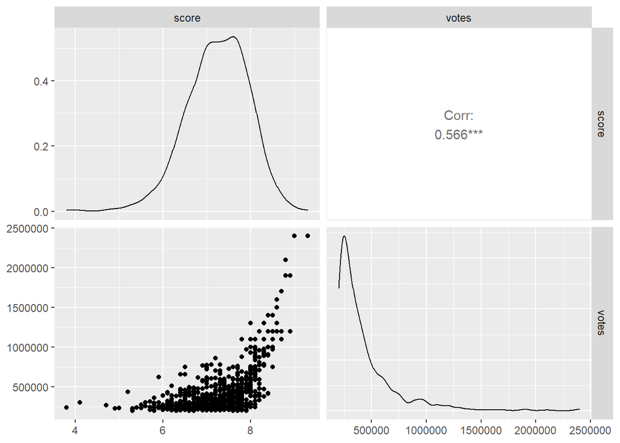

```r
# From above note extremely high variability
movies_q1_1 <- movies[movies$votes >= 200000,]
ggpairs(movies_q1_1[c("score", "votes")])
```

```r
mean(movies$score)
```

```
## [1] 6.334104
```

```r
mean_q1_2 <- movies[movies$votes <= 1000,]
mean(mean_q1_2$score)
```

```
## [1] 5.3
```

```r
mean_q1_3 <- movies[movies$votes >= 500000,]
mean(mean_q1_3$score)
```

```
## [1] 7.846552
```

```r
# ~~~~~ Responding to Q2 ~~~~~
length(unique(movies))
```

```
## [1] 12
```

```r
# ~~~~~ MODEL 1 ~~~~~
# fit model and summary output
model1 <- lm(formula = score ~ rating + runtime + genre + month + year + votes + budget + gross + return_prop , data = movies)
summary(model1)
```

```
##
## Call:
## lm(formula = score ~ rating + runtime + genre + month + year +
##     votes + budget + gross + return_prop, data = movies)
##
## Residuals:
##     Min      1Q  Median      3Q     Max
## -3.9353 -0.3573  0.0884  0.4697  1.9542
##
## Coefficients:
##                  Estimate Std. Error t value Pr(>|t|)
## (Intercept)     9.348e+00  2.470e+00   3.785 0.000156 ***
## ratingG         2.912e+00  7.359e-01   3.957 7.71e-05 ***
## ratingNC-17     3.402e+00  8.004e-01   4.250 2.19e-05 ***
## ratingPG        2.796e+00  7.306e-01   3.827 0.000132 ***
## ratingPG-13     2.837e+00  7.311e-01   3.881 0.000106 ***
## ratingR         3.008e+00  7.309e-01   4.116 3.93e-05 ***
## ratingTV-MA     3.667e+00  1.033e+00   3.551 0.000388 ***
## ratingUnrated   3.396e+00  7.465e-01   4.549 5.53e-06 ***
## runtime         1.598e-02  8.117e-04  19.691  < 2e-16 ***
## genreAdventure  1.355e-01  5.550e-02   2.441 0.014693 *
## genreAnimation  9.540e-01  6.903e-02  13.821  < 2e-16 ***
## genreBiography  5.974e-01  5.859e-02  10.195  < 2e-16 ***
## genreComedy     1.512e-01  3.204e-02   4.718 2.45e-06 ***
## genreCrime      2.824e-01  4.889e-02   5.777 8.15e-09 ***
## genreDrama      3.355e-01  3.890e-02   8.626  < 2e-16 ***
## genreFamily     3.945e-01  3.684e-01   1.071 0.284289
## genreFantasy   -1.116e-01  1.276e-01  -0.874 0.381975
## genreHorror    -2.853e-01  5.786e-02  -4.930 8.52e-07 ***
## genreMystery   -8.705e-02  2.039e-01  -0.427 0.669526
## genreRomance    6.119e-01  4.215e-01   1.452 0.146622
## genreSci-Fi     3.147e-01  3.267e-01   0.963 0.335530
## genreThriller   1.309e-03  2.988e-01   0.004 0.996504
## genreWestern    7.624e-01  7.300e-01   1.044 0.296369
## month2         -4.350e-02  5.755e-02  -0.756 0.449831
## month3         -3.238e-02  5.579e-02  -0.580 0.561644
## month4         -3.914e-02  5.675e-02  -0.690 0.490434
## month5         -2.912e-02  5.839e-02  -0.499 0.618017
## month6         -1.968e-02  5.691e-02  -0.346 0.729471
## month7         -6.257e-02  5.572e-02  -1.123 0.261518
## month8         -6.105e-02  5.378e-02  -1.135 0.256331
## month9          3.236e-02  5.632e-02   0.575 0.565612
## month10        -8.112e-03  5.434e-02  -0.149 0.881347
## month11         4.989e-02  5.579e-02   0.894 0.371230
## month12        -2.601e-02  5.581e-02  -0.466 0.641267
## year           -3.962e-03  1.186e-03  -3.341 0.000842 ***
## votes           2.360e-06  7.950e-08  29.683  < 2e-16 ***
## budget         -4.807e-09  4.537e-10 -10.594  < 2e-16 ***
## gross           2.159e-10  9.990e-11   2.161 0.030769 *
## return_prop     3.350e-05  5.406e-05   0.620 0.535569
## ---
## Signif. codes:  0 '***' 0.001 '**' 0.01 '*' 0.05 '.' 0.1 ' ' 1
##
## Residual standard error: 0.7276 on 4286 degrees of freedom
## Multiple R-squared:  0.4173, Adjusted R-squared:  0.4122
## F-statistic: 80.78 on 38 and 4286 DF,  p-value: < 2.2e-16
```

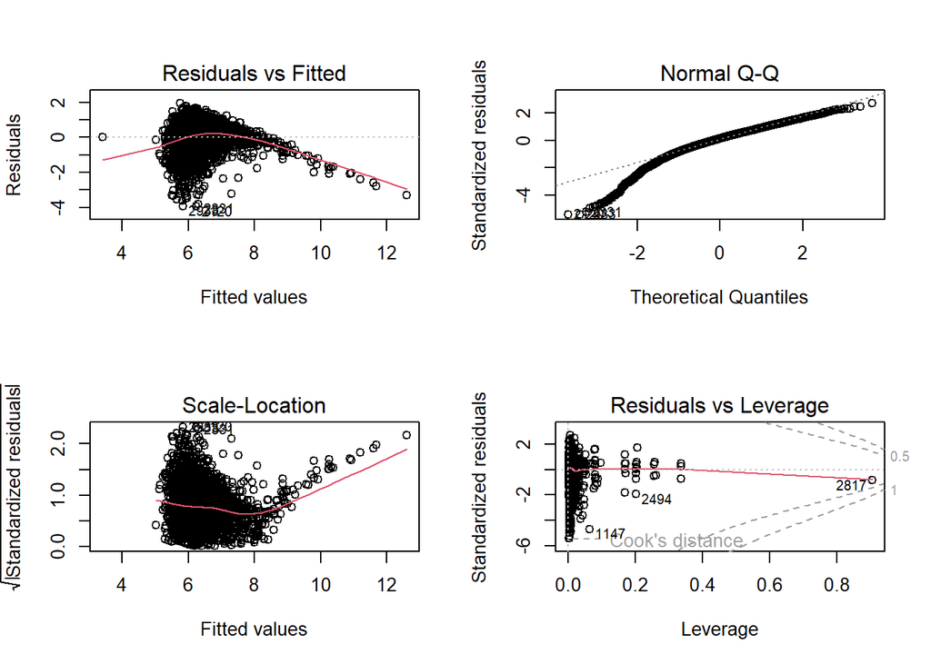

```r
# residual analysis
par(mfrow=c(2,2))
plot(model1)
```

```r
par(mfrow=c(1,1))
```

From the Residuals vs Fitted plot, the residuals are not linear and exhibit heteroskedasticity. The QQ plot suggests that the residuals are not normally distributed as the lower and higher standardized residuals do not line up with the theoretical quantiles. We do have some outliers as well as one particularly high leverage point observations 2817 (The 2007 movie “Paranormal Activity”).

```r
# Model Selection

## Forward selection
model1_forward <- regsubsets(score ~ rating + runtime + genre + month + year + votes + budget + gross + return_prop,
                           data = movies, method = "forward")
cbind(summary(model1_forward)$which, "adjusted r^2" = summary(model1_forward)$adjr2)
```

```
##   (Intercept) ratingG ratingNC-17 ratingPG ratingPG-13 ratingR ratingTV-MA
## 1           1       0           0        0           0       0           0
## 2           1       0           0        0           0       0           0
## 3           1       0           0        0           0       0           0
## 4           1       0           0        0           0       0           0
## 5           1       0           0        0           0       0           0
## 6           1       0           0        0           0       0           0
## 7           1       0           0        0           0       1           0
## 8           1       0           0        0           0       1           0
##   ratingUnrated runtime genreAdventure genreAnimation genreBiography
## 1             0       0              0              0              0
## 2             0       1              0              0              0
## 3             0       1              0              0              0
## 4             0       1              0              1              0
## 5             0       1              0              1              1
```

[output cut: 39 more lines]

```r
## Backward selection
model1_backward <- regsubsets(score ~ rating + runtime + genre + month + year + votes + budget + gross + return_prop,
                           data = movies, method = "backward")
cbind(summary(model1_backward)$which, "adjusted r^2" = summary(model1_backward)$adjr2)
```

```
##   (Intercept) ratingG ratingNC-17 ratingPG ratingPG-13 ratingR ratingTV-MA
## 1           1       0           0        0           0       0           0
## 2           1       0           0        0           0       0           0
## 3           1       0           0        0           0       0           0
## 4           1       0           0        0           0       0           0
## 5           1       0           0        0           0       0           0
## 6           1       0           0        0           0       0           0
## 7           1       0           0        0           0       1           0
## 8           1       0           0        0           0       1           0
##   ratingUnrated runtime genreAdventure genreAnimation genreBiography
## 1             0       0              0              0              0
## 2             0       1              0              0              0
## 3             0       1              0              0              0
## 4             0       1              0              1              0
## 5             0       1              0              1              1
```

[output cut: 39 more lines]

Using a step-wise model selection procedure with $R^2_{adj}$ as a selection criterion, we will choose a model which produces the maximum value for $R^2_{adj}$. This method will implement partial F-tests and then one-by-one eliminate the least significant predictor. In this case, per both backward and forward elimination, the suggested model is score ~ ratingR, runtime, genreAnimation, genreBiography, genreDrama, genreHorror, votes, budget.

Since only 1 of 8 levels for *rating* is deemed significant, and only 4 of 15 levels for *genre* is deemed significant. We will drop these predictors along with *return_prop*, *gross*, *year*, and *month* from the model and analyze the model again.

```r
# ~~~~~ MODEL 2 ~~~~~~~~~
# fit model and summary output
model2 <- lm(formula = score ~ runtime + votes + budget, data = movies)
summary(model2)
```

```
##
## Call:
## lm(formula = score ~ runtime + votes + budget, data = movies)
##
## Residuals:
##     Min      1Q  Median      3Q     Max
## -4.1117 -0.3932  0.0716  0.5118  2.0420
##
## Coefficients:
##               Estimate Std. Error t value Pr(>|t|)
## (Intercept)  4.453e+00  7.611e-02   58.50   <2e-16 ***
## runtime      1.656e-02  7.373e-04   22.46   <2e-16 ***
## votes        2.454e-06  7.329e-08   33.49   <2e-16 ***
## budget      -4.898e-09  3.164e-10  -15.48   <2e-16 ***
## ---
## Signif. codes:  0 '***' 0.001 '**' 0.01 '*' 0.05 '.' 0.1 ' ' 1
##
## Residual standard error: 0.7726 on 4321 degrees of freedom
## Multiple R-squared:  0.3377, Adjusted R-squared:  0.3372
## F-statistic: 734.4 on 3 and 4321 DF,  p-value: < 2.2e-16
```

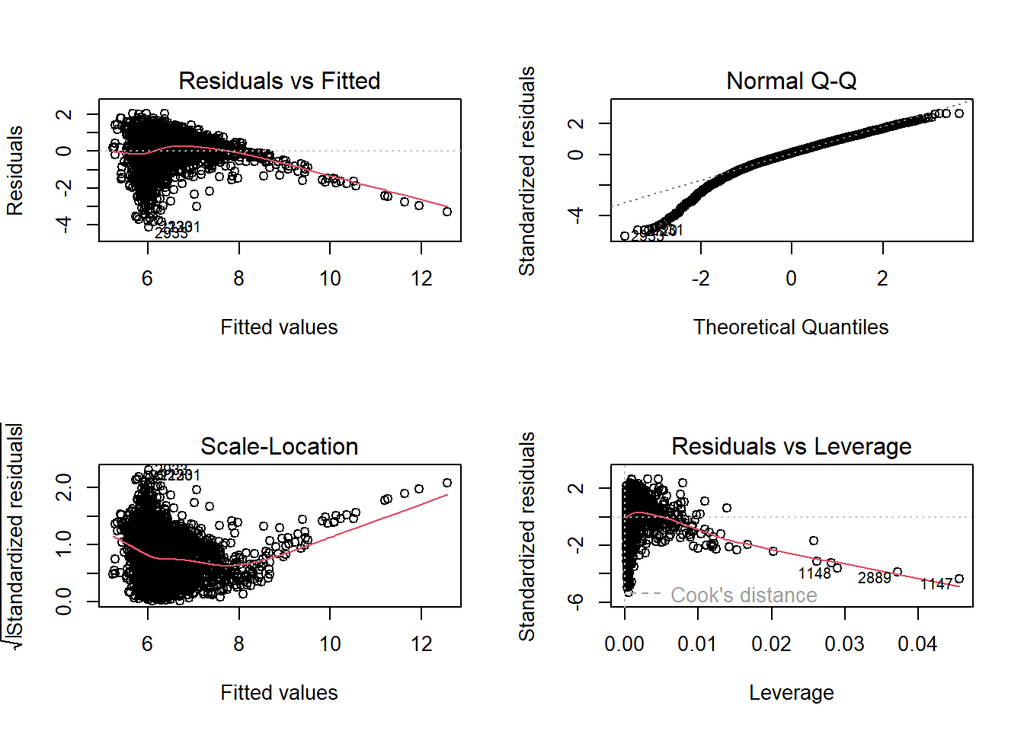

```r
# residual analysis
par(mfrow=c(2,2))
plot(model2)
```

```r
par(mfrow=c(1,1))
```

Residuals vs Fitted: non-linearity, heteroskedasticity

QQ-Plot: non-normality

scale-location: possible outliers

Residuals vs Leverage: high leverage points (1148, 2889,1147)

Remedy:

Will begin by attempting boxcox transformation to address nonlinearity and nonconstant variance in residuals.

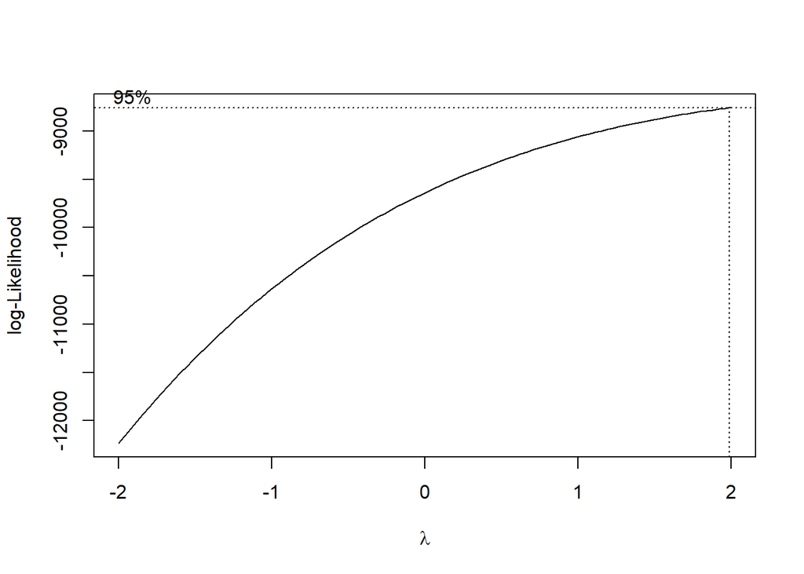

```r
# ~~~~ BoxCox Transformation ~~~~~~
# Boxcox for model2
boxcox(model2)
```

Since the boxcox plot has its maximum value near $\lambda = 2$, we raise $\hat{score}$ to the 2nd power. We fit the new model (model3) as such:

$\hat{score} = \sqrt{\hat\beta_0 + \hat\beta_{\text{runtime}} \cdot \text{runtime} + \hat\beta_{\text{votes}} \cdot \text{votes} + \hat\beta_{\text{budget}} \cdot \text{budget}}$

```r
# ~~~~~ MODEL 3 ~~~~~~~~~
# square outcome variable (score)
score_sq <- (movies$score)^2
# fit model and summary output
model3 <- lm(formula = score_sq ~ runtime + votes + budget, data = movies)
summary(model3)
```

```
##
## Call:
## lm(formula = score_sq ~ runtime + votes + budget, data = movies)
##
## Residuals:
##     Min      1Q  Median      3Q     Max
## -39.308  -5.328   0.187   6.120  28.971
##
## Coefficients:
##               Estimate Std. Error t value Pr(>|t|)
## (Intercept)  1.791e+01  8.875e-01   20.18   <2e-16 ***
## runtime      2.016e-01  8.597e-03   23.45   <2e-16 ***
## votes        3.371e-05  8.546e-07   39.45   <2e-16 ***
## budget      -6.599e-08  3.690e-09  -17.88   <2e-16 ***
## ---
## Signif. codes:  0 '***' 0.001 '**' 0.01 '*' 0.05 '.' 0.1 ' ' 1
##
## Residual standard error: 9.009 on 4321 degrees of freedom
## Multiple R-squared:  0.3949, Adjusted R-squared:  0.3945
## F-statistic: 939.9 on 3 and 4321 DF,  p-value: < 2.2e-16
```

All predictors from model2 are still significant. Adjusted R-squared has increase by $0.3945 - 0.3372 = 0.0573$.

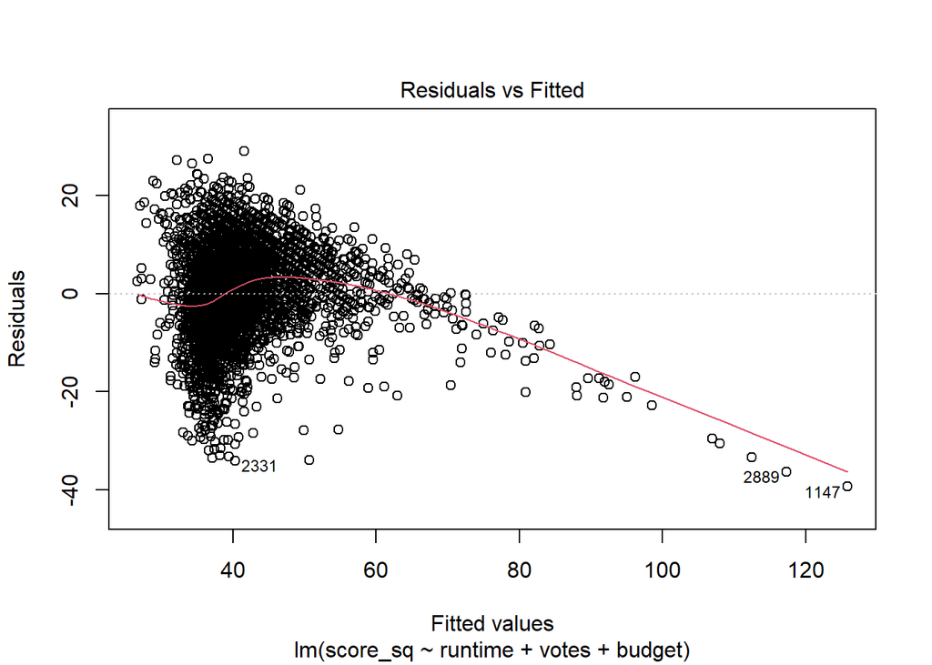

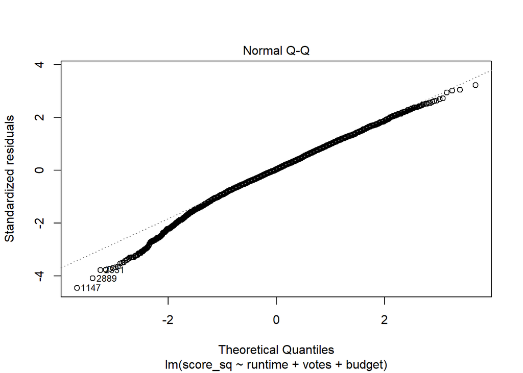

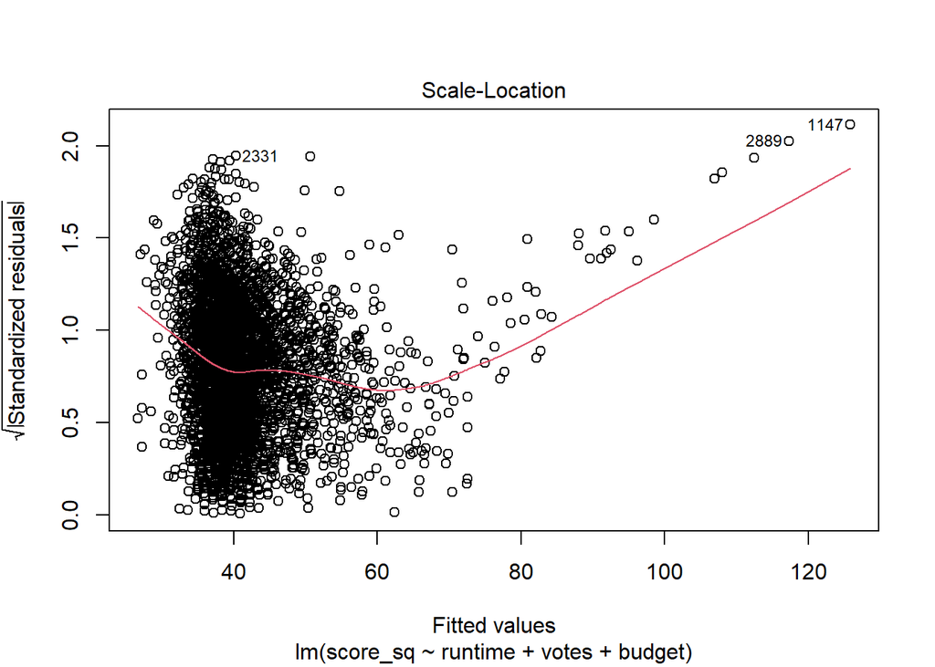

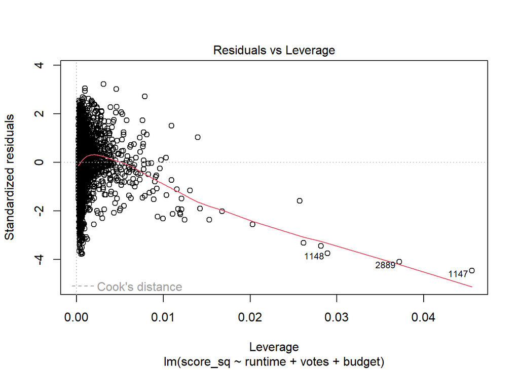

```r
# residual analysis
plot(model3)
```

The transformation has only marginally improved the residual plots. The same issues remain. We can try removing the high leverage points from the model. (Observations 1148,2889,1147).

```r
# ~~~~~ MODEL 4 ~~~~~~~~~

# create vector containing highest leverage points.
# (Pulp Fiction, The Dark Knight, The Shawshank Redemption)
highlev <- c(1148,2889,1147)
movies[highlev,]
```

```
##                          name rating runtime  genre month year   votes score
## 1148             Pulp Fiction      R     154  Crime    10 1994 1900000   8.9
## 2889          The Dark Knight  PG-13     152 Action     7 2008 2400000   9.0
## 1147 The Shawshank Redemption      R     142  Drama    10 1994 2400000   9.3
##        budget      gross return_prop budget_cat
## 1148 8.00e+06  213928762   26.741095        low
## 2889 1.85e+08 1005973645    5.437695       high
## 1147 2.50e+07   28817291    1.152692        low
```

```r
# new dataframe without high leverage points
movies_lowlev <- movies[-highlev,]
rownames(movies_lowlev) <- 1:nrow(movies_lowlev)

# have to remove same values in score_sq
score_sq_ll <- score_sq[-highlev]

# fit model and summary output
model4 <- lm(formula = score_sq_ll ~ runtime + votes + budget, data = movies_lowlev)
summary(model4)
```

```
##
## Call:
## lm(formula = score_sq_ll ~ runtime + votes + budget, data = movies_lowlev)
##
## Residuals:
##     Min      1Q  Median      3Q     Max
## -34.375  -5.289   0.170   6.027  28.763
##
## Coefficients:
##               Estimate Std. Error t value Pr(>|t|)
## (Intercept)  1.799e+01  8.823e-01   20.39   <2e-16 ***
## runtime      2.000e-01  8.550e-03   23.39   <2e-16 ***
## votes        3.588e-05  8.978e-07   39.96   <2e-16 ***
## budget      -6.942e-08  3.701e-09  -18.76   <2e-16 ***
## ---
## Signif. codes:  0 '***' 0.001 '**' 0.01 '*' 0.05 '.' 0.1 ' ' 1
##
## Residual standard error: 8.955 on 4318 degrees of freedom
## Multiple R-squared:  0.3972, Adjusted R-squared:  0.3968
## F-statistic: 948.5 on 3 and 4318 DF,  p-value: < 2.2e-16
```

All predictors still significant. Adjusted R-squared improved by $0.3968 - 0.3945 = 0.0023$.

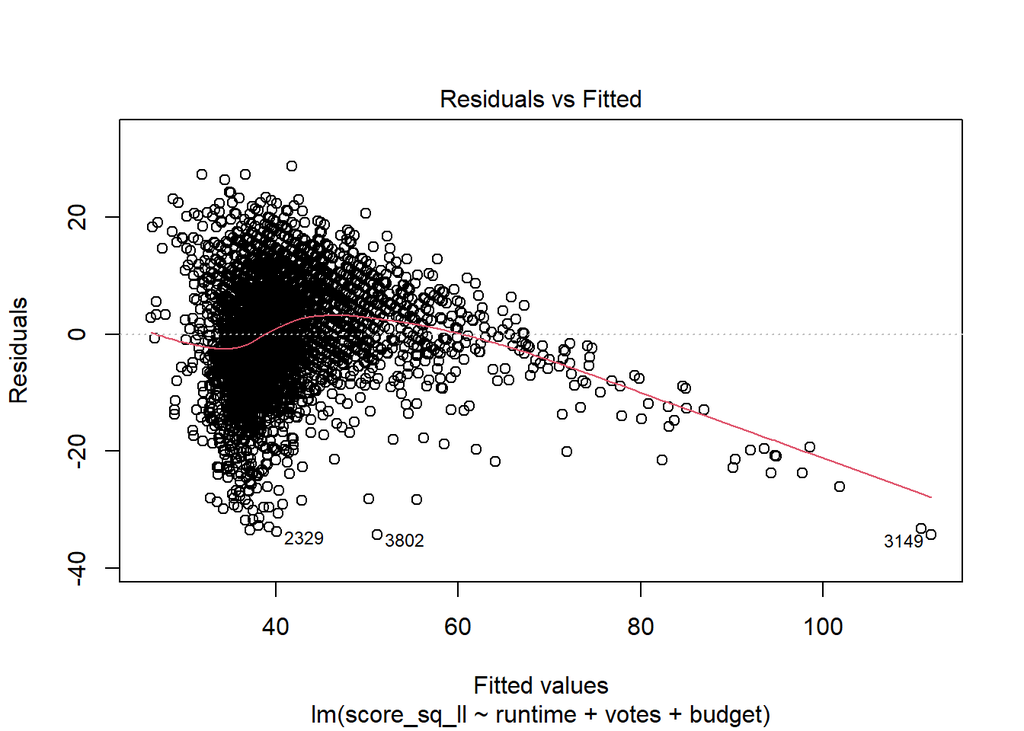

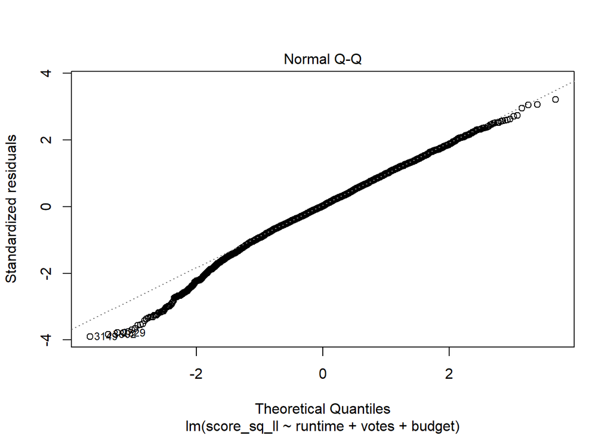

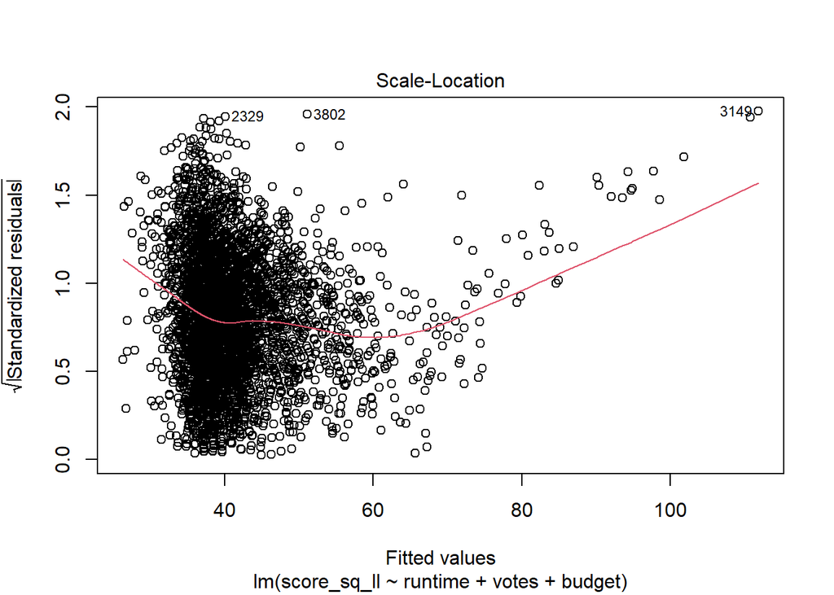

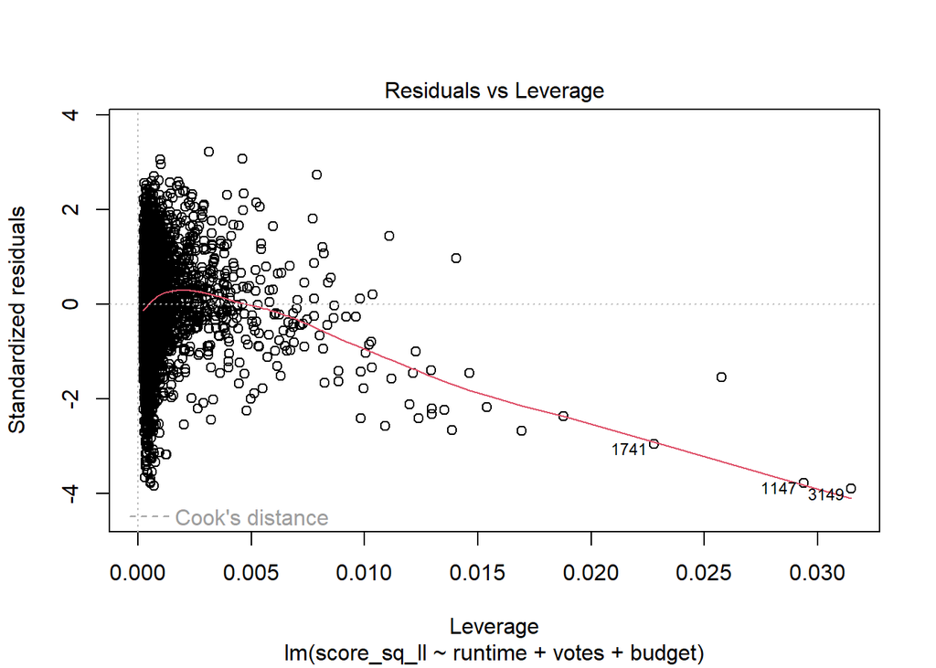

```r
# residual analysis
plot(model4)
```

```r
# high leverage
hl_2 <- c(1741,1147,3149)
movies_lowlev[hl_2,]
```

```
##              name rating runtime  genre month year   votes score  budget
## 1741   The Matrix      R     136 Action     3 1999 1700000   8.7 6.3e+07
## 1147 Forrest Gump  PG-13     142  Drama     7 1994 1900000   8.8 5.5e+07
## 3149    Inception  PG-13     148 Action     7 2010 2100000   8.8 1.6e+08
##          gross return_prop budget_cat
## 1741 466364845    7.402617        low
## 1147 678226133   12.331384        low
## 3149 836836967    5.230231       high
```

```r
# seems like the movies that keep throwing off the model are those that are "big hits" or "classics"
```

Seems like the movies that keep throwing off the model are those that are “big hits” or “classics”. Will, again, remove these observations.

```r
# ~~~~~ MODEL 5 ~~~~~~~~~

# new dataframe without high leverage points
movies_lowlev2 <- movies_lowlev[-hl_2,]
rownames(movies_lowlev2) <- 1:nrow(movies_lowlev2)

# have to remove same values in score_sq_ll
score_sq_ll2 <- score_sq_ll[-hl_2]

# fit model and summary output
model5 <- lm(formula = score_sq_ll2 ~ runtime + votes + budget, data = movies_lowlev2)
summary(model5)
```

```
##
## Call:
## lm(formula = score_sq_ll2 ~ runtime + votes + budget, data = movies_lowlev2)
##
## Residuals:
##     Min      1Q  Median      3Q     Max
## -34.611  -5.291   0.125   6.010  28.539
##
## Coefficients:
##               Estimate Std. Error t value Pr(>|t|)
## (Intercept)  1.807e+01  8.786e-01   20.57   <2e-16 ***
## runtime      1.984e-01  8.516e-03   23.30   <2e-16 ***
## votes        3.755e-05  9.315e-07   40.31   <2e-16 ***
## budget      -7.166e-08  3.703e-09  -19.35   <2e-16 ***
## ---
## Signif. codes:  0 '***' 0.001 '**' 0.01 '*' 0.05 '.' 0.1 ' ' 1
##
## Residual standard error: 8.916 on 4315 degrees of freedom
## Multiple R-squared:  0.3988, Adjusted R-squared:  0.3984
## F-statistic: 954.2 on 3 and 4315 DF,  p-value: < 2.2e-16
```

All predictors still significant. Adjusted R-squared improved by $0.3984 - 0.3968 = 0.0016$.

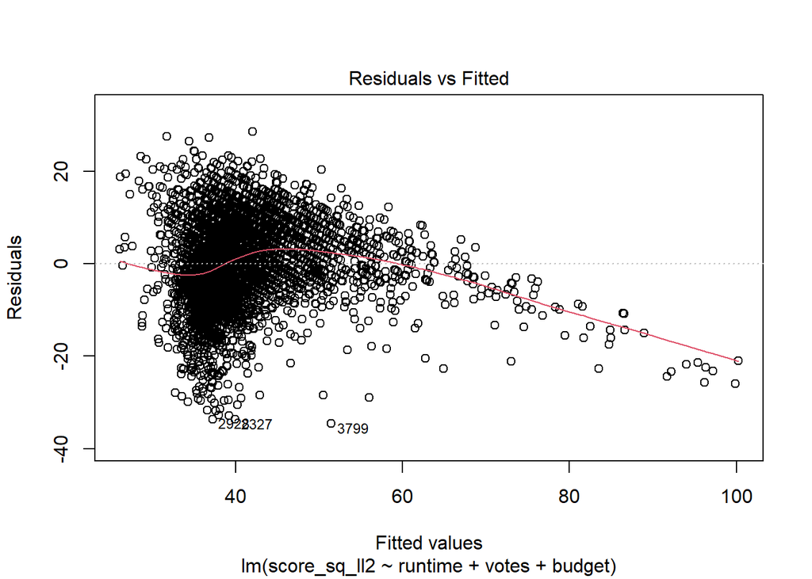

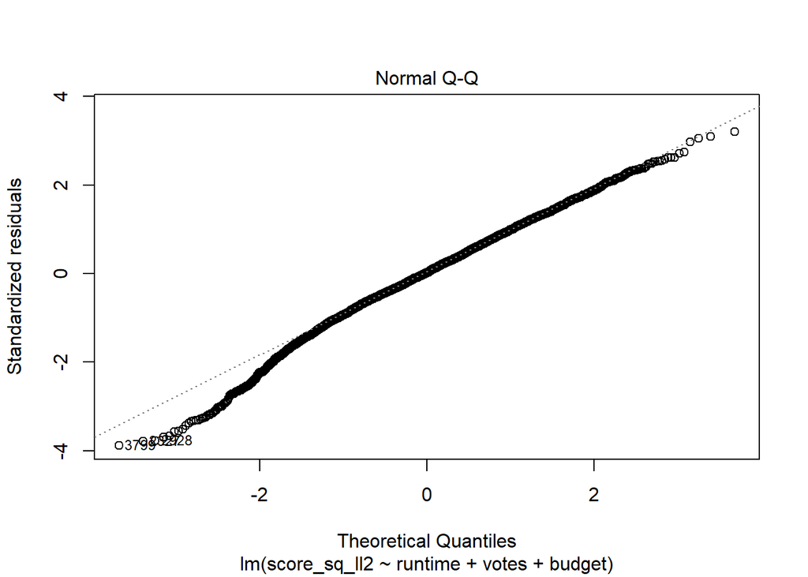

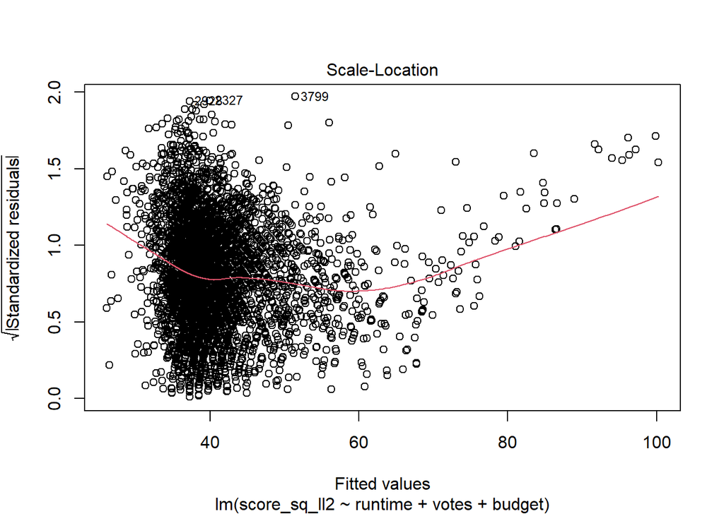

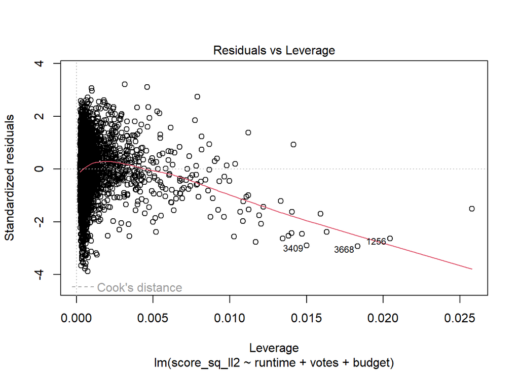

```r
# residual analysis
plot(model5)
```

```r
# high leverage
hl_3 <- c(3409,3668,1256)
movies_lowlev2[hl_3,]
```

```
##                  name rating runtime     genre month year   votes score
## 3409 Django Unchained      R     165     Drama    12 2012 1400000   8.4
## 3668     Interstellar  PG-13     169 Adventure    11 2014 1600000   8.6
## 1256            Se7en      R     127     Crime     9 1995 1500000   8.6
##        budget     gross return_prop budget_cat
## 3409 1.00e+08 426074373    4.260744       high
## 3668 1.65e+08 701729206    4.252904       high
## 1256 3.30e+07 327333559    9.919199        low
```

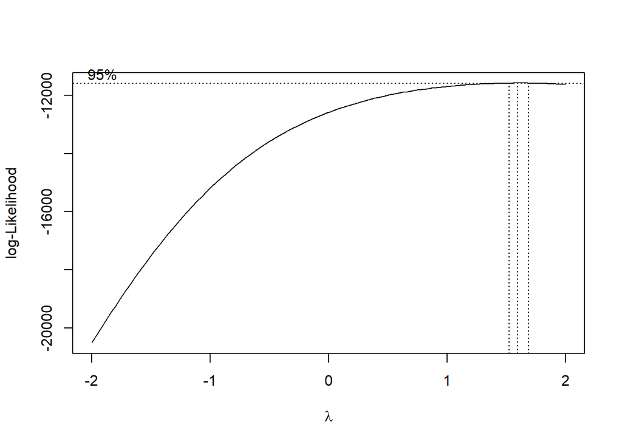

```r
boxcox(model5)
```

```r
# ~~~~~ MODEL 6 ~~~~~~~~~
score_4th <- (score_sq_ll2)^2

# fit model and summary output
model6 <- lm(formula = score_4th ~ runtime + votes + budget, data = movies_lowlev2)
summary(model6)
```

```
##
## Call:
## lm(formula = score_4th ~ runtime + votes + budget, data = movies_lowlev2)
##
## Residuals:
##     Min      1Q  Median      3Q     Max
## -2476.8  -471.3   -73.7   437.7  3030.0
##
## Coefficients:
##               Estimate Std. Error t value Pr(>|t|)
## (Intercept) -3.805e+01  6.754e+01  -0.563    0.573
## runtime      1.571e+01  6.546e-01  23.995   <2e-16 ***
## votes        3.626e-03  7.160e-05  50.646   <2e-16 ***
## budget      -6.713e-06  2.846e-07 -23.586   <2e-16 ***
## ---
## Signif. codes:  0 '***' 0.001 '**' 0.01 '*' 0.05 '.' 0.1 ' ' 1
##
## Residual standard error: 685.3 on 4315 degrees of freedom
## Multiple R-squared:  0.4847, Adjusted R-squared:  0.4844
## F-statistic:  1353 on 3 and 4315 DF,  p-value: < 2.2e-16
```

Adjusted R-squared increased by $0.4844 - 0.3984 = 0.086$

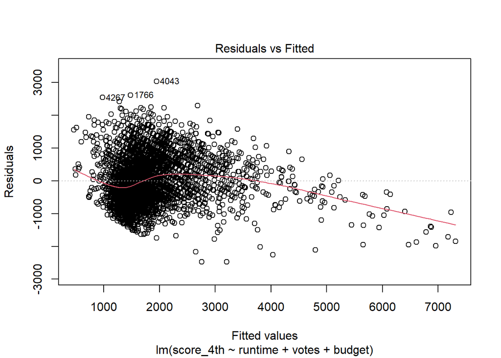

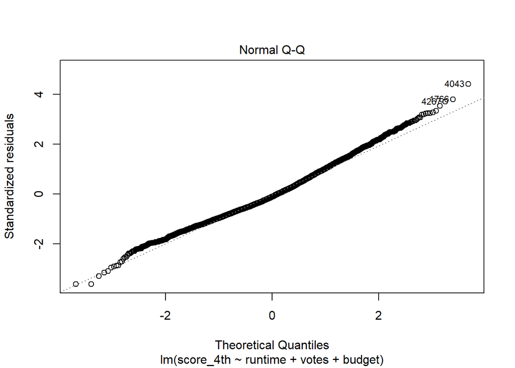

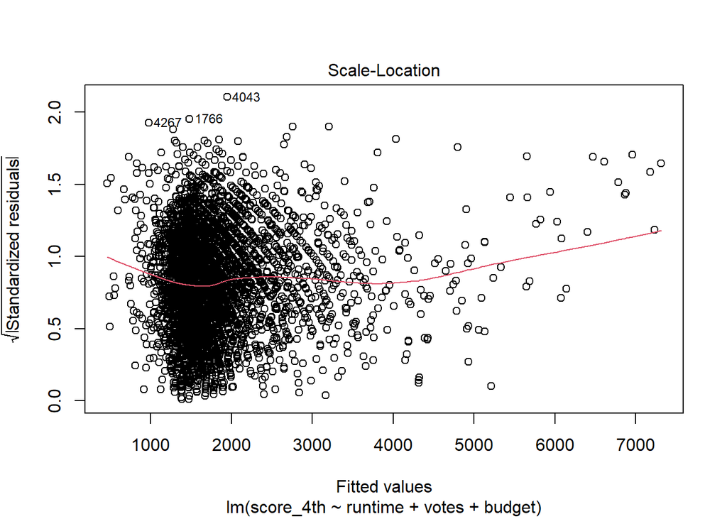

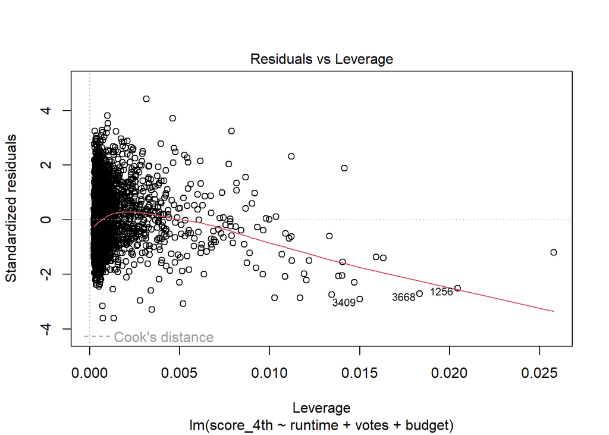

```r
# residual analysis
plot(model6)
```

```r
# ~~~~~~~~ Residual Analysis: Formal Tests ~~~~~~~~

# Shapiro-Wilk Test
# test for normality
# H0: data are normally distributed
shapiro.test(resid(model6))
```

```
##
##  Shapiro-Wilk normality test
##
## data:  resid(model6)
## W = 0.9894, p-value < 2.2e-16
```